# Loan Default Probability Prediction

Jiayi Jiang

2023-04-09

## Predicting Probability of Loan Default

### Summary of the procedures:

#### Step 4: Predict the raw risk score for the test data

#### Step 5: Probability calibration, after this step, I build a complete 600 risk score prediction (calibrated) for each customer in the test set. The result is shown below in the array “cali_pred1”

#### Step 6: Calculate the MAE error of the prediction model: 0.1141 which is very low as desired!

```r
library(readr)
library(Hmisc)
loan_train_final <- read_csv("~/Downloads/loan_train_final.csv")
test_loan <- read_csv("~/Downloads/loan_test_final.csv")
######################### Step 1: Data Processing #########################

####### Treat the missing values:
sum(is.na(loan_train_final))
```

```
## [1] 134
```

```r
sum(is.na(test_loan))
```

```
## [1] 26
```

```r
# describe(loan_train_final)
# describe(test_loan)

# describe(loan_train_final$employment)
# describe(test_loan$employment)

loan_train_final$employment[is.na(loan_train_final$employment)]<- "10+"
test_loan$employment[is.na(test_loan$employment)]<- "10+"



####### Treat the categorical data:
# summary(loan_train_final)
# summary(test_loan)

# describe(loan_train_final$reason)
# describe(test_loan$reason)

loan_train_final$initial_list_status[loan_train_final$initial_list_status == "a"] <- 0
loan_train_final$initial_list_status[loan_train_final$initial_list_status == "b"] <- 1
loan_train_final$initial_list_status <- as.numeric(loan_train_final$initial_list_status)

test_loan$initial_list_status[test_loan$initial_list_status == "a"] <- 0
test_loan$initial_list_status[test_loan$initial_list_status == "b"] <- 1
test_loan$initial_list_status <- as.numeric(test_loan$initial_list_status)

loan_train_final$term[loan_train_final$term == "3 yrs"] <- 0
loan_train_final$term[loan_train_final$term == "5 yrs"] <- 1
loan_train_final$term <- as.numeric(loan_train_final$term)

test_loan$term[test_loan$term == "3 yrs"] <- 0
test_loan$term[test_loan$term == "5 yrs"] <- 1
test_loan$term <- as.numeric(test_loan$term)

####### Factor the text data:
loan_train_final$reason <- as.factor(loan_train_final$reason)
loan_train_final$employment <- as.factor(loan_train_final$employment)
loan_train_final$status <- as.factor(loan_train_final$status)
loan_train_final$quality <- as.factor(loan_train_final$quality)

test_loan$reason <- as.factor(test_loan$reason)
test_loan$employment <- as.factor(test_loan$employment)
test_loan$status <- as.factor(test_loan$status)
test_loan$quality <- as.factor(test_loan$quality)
```

```r
######################### Step 2: Feature Selection #########################

###### Lasso with cross-validation:
library(glmnet)
```

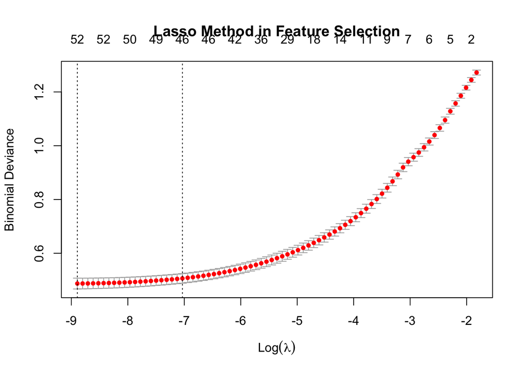

```r
x_train <- model.matrix(default~., data = loan_train_final)[,-1]
x_test <- model.matrix(default~., data = test_loan)[,-1]
y_train <- loan_train_final$default
y_test <- test_loan$default

set.seed(8776)
cv.lasso <- cv.glmnet(x_train, y_train, family = 'binomial')
plot(cv.lasso, main = "Lasso Method in Feature Selection")
```

```
## <sparse>[ <logic> ]: .M.sub.i.logical() maybe inefficient
```

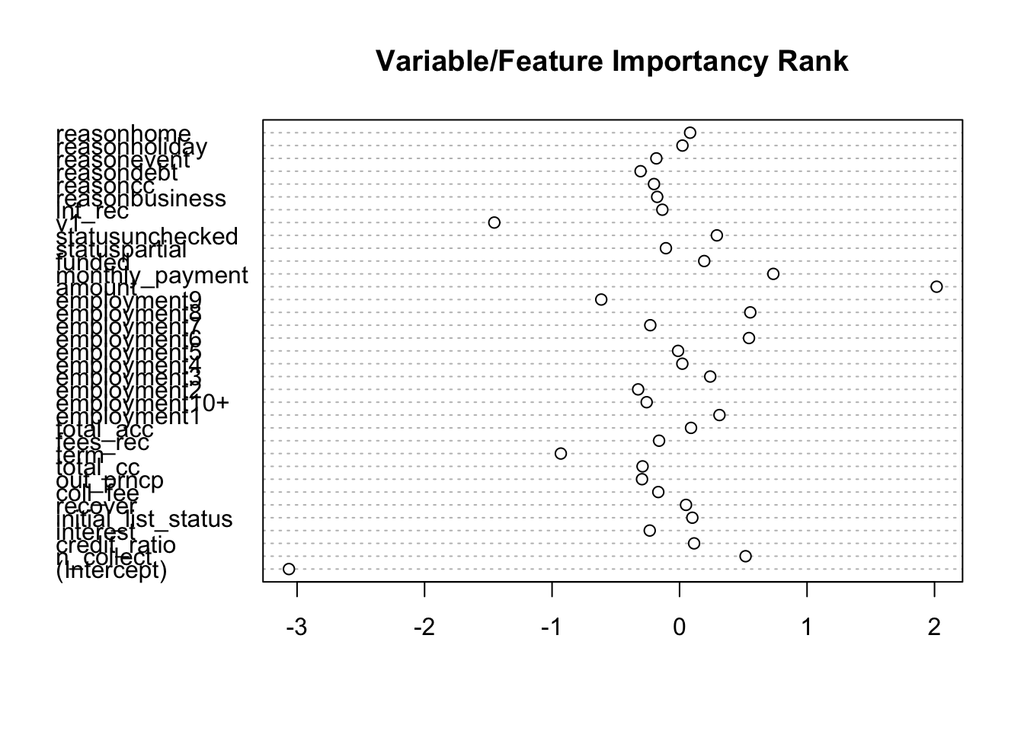

```r
beta <- coef(cv.lasso, s = "lambda.1se")
label <- beta@Dimnames[[1]]
dotchart(beta[abs(beta)>0.01], labels = label, main = "Variable/Feature Importancy Rank")
```

```r
######################### Step 3: Train the logistic model #########################
library(rfUtilities)

formal1 = as.formula(default~n_collect+interest+initial_list_status+term+fees_rec+employment+status+v1+reason+quality+violations+del+req)

model1 <- glm(formal1, data = loan_train_final, family = "binomial")
summary(model1)
```

```
##
## Call:
## glm(formula = formal1, family = "binomial", data = loan_train_final)
##
## Deviance Residuals:
##     Min       1Q   Median       3Q      Max
## -3.2361  -0.8354  -0.5835   1.0551   2.3242
##
## Coefficients:
##                       Estimate Std. Error z value Pr(>|z|)
## (Intercept)          -3.536796   0.481307  -7.348 2.01e-13 ***
## n_collect            -0.192087   0.444808  -0.432 0.665856
## interest              0.356571   0.037054   9.623  < 2e-16 ***
## initial_list_status  -0.481261   0.101057  -4.762 1.91e-06 ***
## term                 -0.186363   0.121651  -1.532 0.125536
## fees_rec              0.060537   0.011644   5.199 2.01e-07 ***
## employment1          -0.450230   0.249291  -1.806 0.070912 .
## employment10+        -0.597130   0.178852  -3.339 0.000842 ***
## employment2          -0.542846   0.226622  -2.395 0.016603 *
## employment3          -0.620575   0.227581  -2.727 0.006395 **
## employment4          -0.357628   0.241137  -1.483 0.138050
## employment5          -0.489746   0.248731  -1.969 0.048955 *
## employment6          -0.332747   0.260729  -1.276 0.201879
## employment7          -0.370426   0.252368  -1.468 0.142158
## employment8          -0.252181   0.267643  -0.942 0.346076
## employment9          -0.616314   0.280774  -2.195 0.028160 *
## statuspartial         0.037537   0.115052   0.326 0.744224
## statusunchecked       0.011074   0.125247   0.088 0.929545
## v1                   -0.005699   0.006055  -0.941 0.346599
## reasonbusiness        1.117324   0.465435   2.401 0.016368 *
## reasoncc             -0.116264   0.341440  -0.341 0.733472
## reasondebt            0.006220   0.329393   0.019 0.984935
## reasonevent           1.930428   1.261380   1.530 0.125915
## reasonholiday         0.017203   0.636384   0.027 0.978434
## reasonhome            1.502763   0.911647   1.648 0.099269 .
## reasonmedical         0.628096   0.570846   1.100 0.271206
## reasonmoving          0.517572   0.530234   0.976 0.329005
## reasonother           0.107596   0.375256   0.287 0.774321
## reasonrenovation     -0.271294   0.385584  -0.704 0.481687
## reasonsolar         -11.547807 228.799011  -0.050 0.959747
## reasontransport       0.030023   0.581190   0.052 0.958802
## qualityq2            -0.840911   0.240965  -3.490 0.000483 ***
## qualityq3            -1.642059   0.315610  -5.203 1.96e-07 ***
## qualityq4            -2.126720   0.411831  -5.164 2.42e-07 ***
## qualityq5            -3.058167   0.516809  -5.917 3.27e-09 ***
## qualityq6            -3.823126   0.653157  -5.853 4.82e-09 ***
## qualityq7            -3.698967   0.810675  -4.563 5.05e-06 ***
## violations           -0.311404   0.107886  -2.886 0.003897 **
## del                  -0.044171   0.052311  -0.844 0.398455
## req                   0.116841   0.041337   2.827 0.004706 **
## ---
## Signif. codes:  0 '***' 0.001 '**' 0.01 '*' 0.05 '.' 0.1 ' ' 1
##
## (Dispersion parameter for binomial family taken to be 1)
##
##     Null deviance: 3058.0  on 2399  degrees of freedom
## Residual deviance: 2645.8  on 2360  degrees of freedom
## AIC: 2725.8
##
## Number of Fisher Scoring iterations: 11
```

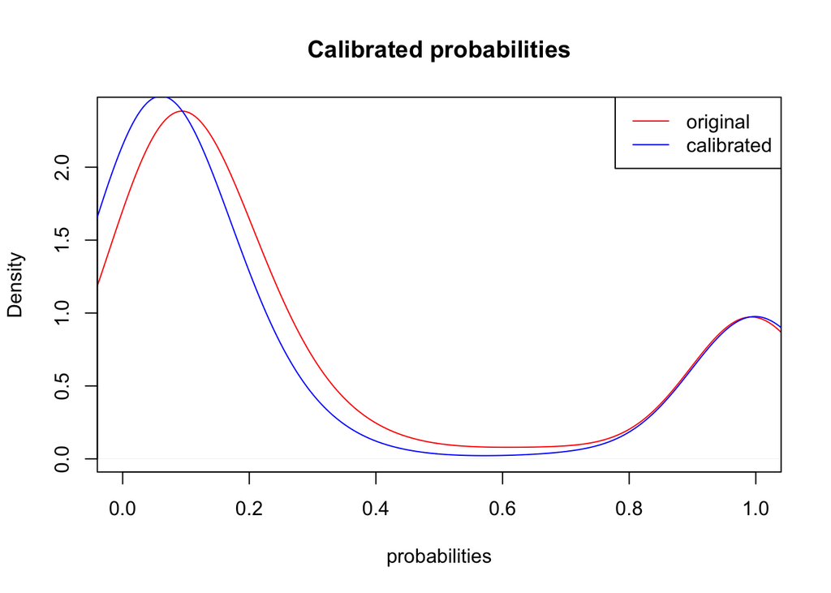

```r
######################### Step 4: Predict the risk score  #########################

pred_model1 <- predict(model1,test_loan, type="response")
pred2<-predict(cv.lasso,x_test,type='response')


######################### Step 5: Probability Calibration  #########################
cali_pred1<-probability.calibration(test_loan$default, pred2, regularization = FALSE)

plot(density(pred2), col="red", xlim=c(0,1), ylab="Density", xlab="probabilities",
      main="Calibrated probabilities" )
lines(density(cali_pred1), col="blue")
legend("topright", legend=c("original","calibrated"),
                lty = c(1,1), col=c("red","blue"))
```

```r
######################### Final Output: Loan Default Probability for Each Customer in Test Dataset #########################
cali_pred1
```

```
##   [1] 5.943944e-02 6.018878e-02 4.297436e-02 1.000000e+00 1.000000e+00
##   [6] 4.294778e-02 7.047477e-02 2.868334e-02 1.792751e-02 6.916190e-02
##  [11] 5.040673e-02 4.122400e-02 1.021128e-02 1.000000e+00 1.193075e-02
##  [16] 6.619830e-02 1.000000e+00 1.000000e+00 5.582803e-02 7.662080e-03
##  [21] 7.145856e-02 5.420766e-02 2.545986e-01 1.000000e+00 2.551261e-02
##  [26] 4.631982e-02 1.000000e+00 6.038957e-02 6.589336e-02 1.000000e+00
##  [31] 1.835395e-01 5.516305e-02 7.315407e-02 7.276469e-02 1.582387e-01
##  [36] 2.654743e-02 7.213950e-02 1.000000e+00 2.308218e-02 1.900644e-02
##  [41] 2.557899e-02 6.131574e-02 1.325079e-01 4.944862e-02 1.738068e-01
##  [46] 2.117081e-02 1.000000e+00 1.486869e-01 5.408785e-02 6.358809e-02
##  [51] 2.127584e-01 6.305899e-02 1.000000e+00 9.359993e-03 1.472137e-03
##  [56] 3.203502e-02 1.230530e-01 6.791311e-02 2.922291e-02 5.499662e-02
##  [61] 3.716746e-03 1.000000e+00 6.529998e-02 7.113301e-01 2.729634e-01
##  [66] 2.124367e-01 1.849495e-01 0.000000e+00 2.719880e-01 3.211263e-02
##  [71] 1.357455e-01 1.000000e+00 2.275113e-01 3.161350e-02 1.005840e-01
```

[output cut: 105 more lines]

```r
######################### Step 6: Evaluation: Calculate MAE error of the prediction  ##########################

mean(abs(y_test-cali_pred1))
```

```
## [1] 0.1141143
```